# Project: Wrangling and Analyze Data

### 2 - Image Prediction

#### Define

- Modify current Prediction columns to be more descriptive

```python
# View image prediction column names and structure prior to changes
image_prediction_cleaned.info()
```

```
<class 'pandas.core.frame.DataFrame'>
RangeIndex: 2075 entries, 0 to 2074
Data columns (total 12 columns):
tweet_id    2075 non-null int64
jpg_url     2075 non-null object
img_num     2075 non-null int64
p1          2075 non-null object
p1_conf     2075 non-null float64
p1_dog      2075 non-null bool
p2          2075 non-null object
p2_conf     2075 non-null float64
p2_dog      2075 non-null bool
p3          2075 non-null object
p3_conf     2075 non-null float64
p3_dog      2075 non-null bool
dtypes: bool(3), float64(3), int64(2), object(4)
memory usage: 152.1+ KB
```

#### Code

```python
# Update Prediction columns to make more sense
image_prediction_cleaned = image_prediction_cleaned.rename(columns = {
                                  'p1': 'Prediction1', 'p1_conf': 'Prediction1_Conf', 'p1_dog': 'Prediction1_Dog',
                                  'p2': 'Prediction2', 'p2_conf': 'Prediction2_Conf', 'p2_dog': 'Prediction2_dog',
                                  'p3': 'Prediction3', 'p3_conf': 'Prediction3_Conf', 'p3_dog': 'Prediction3_dog'})
```

#### Test

```python
# Check renaming of Prediction columns
image_prediction_cleaned.info()
```

```
<class 'pandas.core.frame.DataFrame'>
RangeIndex: 2075 entries, 0 to 2074
Data columns (total 12 columns):
tweet_id            2075 non-null int64
jpg_url             2075 non-null object
img_num             2075 non-null int64
Prediction1         2075 non-null object
Prediction1_Conf    2075 non-null float64
Prediction1_Dog     2075 non-null bool
Prediction2         2075 non-null object
Prediction2_Conf    2075 non-null float64
Prediction2_dog     2075 non-null bool
Prediction3         2075 non-null object
Prediction3_Conf    2075 non-null float64
Prediction3_dog     2075 non-null bool
dtypes: bool(3), float64(3), int64(2), object(4)
memory usage: 152.1+ KB
```

#### Define

- Drop duplicate images

```python
# Verify duplicate count prior to dropping
image_prediction_cleaned.jpg_url.duplicated().sum()
```

```
66
```

```python
# Drop duplicate jpg_url images
image_prediction_cleaned = image_prediction_cleaned.drop_duplicates(subset = ['jpg_url'], keep='first')
```

```python
# Verify that there aren't any duplicates
image_prediction_cleaned.jpg_url.duplicated().sum()
```

```
0
```

#### Define

- Remove the img_num column

#### Code

```python
# Drop the img_num column
image_prediction_cleaned = image_prediction_cleaned.drop('img_num',1)
```

#### Test

```python
# Verify that the img_num column has been dropped
image_prediction_cleaned.info()
```

```
<class 'pandas.core.frame.DataFrame'>
Int64Index: 2009 entries, 0 to 2074
Data columns (total 11 columns):
tweet_id            2009 non-null int64
jpg_url             2009 non-null object
Prediction1         2009 non-null object
Prediction1_Conf    2009 non-null float64
Prediction1_Dog     2009 non-null bool
Prediction2         2009 non-null object
Prediction2_Conf    2009 non-null float64
Prediction2_dog     2009 non-null bool
Prediction3         2009 non-null object
Prediction3_Conf    2009 non-null float64
Prediction3_dog     2009 non-null bool
dtypes: bool(3), float64(3), int64(1), object(4)
memory usage: 147.1+ KB
```

#### Define

- Capitalize the first letter of the Prediction column

#### Code

```python
image_prediction_cleaned.Prediction1 = image_prediction_cleaned.Prediction1.str.capitalize()
image_prediction_cleaned.Prediction2 = image_prediction_cleaned.Prediction2.str.capitalize()
image_prediction_cleaned.Prediction3 = image_prediction_cleaned.Prediction3.str.capitalize()
```

#### Test

```python
# View values in Prediction columns for Capitalization
image_prediction_cleaned.head()
```

|  | tweet_id | jpg_url | Prediction1 | Prediction1_Conf | Prediction1_Dog | Prediction2 | Prediction2_Conf | Prediction2_dog | Prediction3 | Prediction3_Conf | Prediction3_dog |
| --- | --- | --- | --- | --- | --- | --- | --- | --- | --- | --- | --- |
| 0 | 666020888022790149 | https://pbs.twimg.com/media/CT4udn0WwAA0aMy.jpg | Welsh_springer_spaniel | 0.465074 | True | Collie | 0.156665 | True | Shetland_sheepdog | 0.061428 | True |
| 1 | 666029285002620928 | https://pbs.twimg.com/media/CT42GRgUYAA5iDo.jpg | Redbone | 0.506826 | True | Miniature_pinscher | 0.074192 | True | Rhodesian_ridgeback | 0.072010 | True |
| 2 | 666033412701032449 | https://pbs.twimg.com/media/CT4521TWwAEvMyu.jpg | German_shepherd | 0.596461 | True | Malinois | 0.138584 | True | Bloodhound | 0.116197 | True |
| 3 | 666044226329800704 | https://pbs.twimg.com/media/CT5Dr8HUEAA-lEu.jpg | Rhodesian_ridgeback | 0.408143 | True | Redbone | 0.360687 | True | Miniature_pinscher | 0.222752 | True |
| 4 | 666049248165822465 | https://pbs.twimg.com/media/CT5IQmsXIAAKY4A.jpg | Miniature_pinscher | 0.560311 | True | Rottweiler | 0.243682 | True | Doberman | 0.154629 | True |

### 3 - Tweet (JSON)

#### Define

- Rename the 'id' column to tweet_id to match the other two dataset

```python
# View column names and structure prior to any changes
tweet_selected_attr_cleaned.info()
```

```
<class 'pandas.core.frame.DataFrame'>
RangeIndex: 2354 entries, 0 to 2353
Data columns (total 31 columns):
contributors                     0 non-null float64
coordinates                      0 non-null float64
created_at                       2354 non-null datetime64[ns]
display_text_range               2354 non-null object
entities                         2354 non-null object
extended_entities                2073 non-null object
favorite_count                   2354 non-null int64
favorited                        2354 non-null bool
full_text                        2354 non-null object
geo                              0 non-null float64
id                               2354 non-null int64
id_str                           2354 non-null int64
in_reply_to_screen_name          78 non-null object
in_reply_to_status_id            78 non-null float64
in_reply_to_status_id_str        78 non-null float64
in_reply_to_user_id              78 non-null float64
in_reply_to_user_id_str          78 non-null float64
is_quote_status                  2354 non-null bool
lang                             2354 non-null object
place                            1 non-null object
possibly_sensitive               2211 non-null float64
possibly_sensitive_appealable    2211 non-null float64
quoted_status                    28 non-null object
quoted_status_id                 29 non-null float64
quoted_status_id_str             29 non-null float64
retweet_count                    2354 non-null int64
retweeted                        2354 non-null bool
retweeted_status                 179 non-null object
source                           2354 non-null object
truncated                        2354 non-null bool
user                             2354 non-null object
dtypes: bool(4), datetime64[ns](1), float64(11), int64(4), object(11)
memory usage: 505.8+ KB
```

#### Code

```python
# Rename the id column
tweet_selected_attr_cleaned = tweet_selected_attr_cleaned.rename(columns = {
    'id':'tweet_id'
})
```

#### Test

```python
# View updated column name
tweet_selected_attr_cleaned.info()
```

```
<class 'pandas.core.frame.DataFrame'>
RangeIndex: 2354 entries, 0 to 2353
Data columns (total 31 columns):
contributors                     0 non-null float64
coordinates                      0 non-null float64
created_at                       2354 non-null datetime64[ns]
display_text_range               2354 non-null object
entities                         2354 non-null object
extended_entities                2073 non-null object
favorite_count                   2354 non-null int64
favorited                        2354 non-null bool
full_text                        2354 non-null object
geo                              0 non-null float64
tweet_id                         2354 non-null int64
id_str                           2354 non-null int64
in_reply_to_screen_name          78 non-null object
in_reply_to_status_id            78 non-null float64
in_reply_to_status_id_str        78 non-null float64
in_reply_to_user_id              78 non-null float64
in_reply_to_user_id_str          78 non-null float64
is_quote_status                  2354 non-null bool
lang                             2354 non-null object
place                            1 non-null object
possibly_sensitive               2211 non-null float64
possibly_sensitive_appealable    2211 non-null float64
quoted_status                    28 non-null object
quoted_status_id                 29 non-null float64
quoted_status_id_str             29 non-null float64
retweet_count                    2354 non-null int64
retweeted                        2354 non-null bool
retweeted_status                 179 non-null object
source                           2354 non-null object
truncated                        2354 non-null bool
user                             2354 non-null object
dtypes: bool(4), datetime64[ns](1), float64(11), int64(4), object(11)
memory usage: 505.8+ KB
```

#### Define

- Remove retweet in the dataset

#### Code

```python
# Remove retweet status information
tweet_selected_attr_cleaned = tweet_selected_attr_cleaned[tweet_selected_attr_cleaned.in_reply_to_status_id_str.isnull()]
tweet_selected_attr_cleaned = tweet_selected_attr_cleaned[tweet_selected_attr_cleaned.retweeted_status.isnull()]
```

#### Test

```python
# After rows information is cleaned up
tweet_selected_attr_cleaned.info()
```

```
<class 'pandas.core.frame.DataFrame'>
Int64Index: 2097 entries, 0 to 2353
Data columns (total 31 columns):
contributors                     0 non-null float64
coordinates                      0 non-null float64
created_at                       2097 non-null datetime64[ns]
display_text_range               2097 non-null object
entities                         2097 non-null object
extended_entities                1971 non-null object
favorite_count                   2097 non-null int64
favorited                        2097 non-null bool
full_text                        2097 non-null object
geo                              0 non-null float64
tweet_id                         2097 non-null int64
id_str                           2097 non-null int64
in_reply_to_screen_name          0 non-null object
in_reply_to_status_id            0 non-null float64
in_reply_to_status_id_str        0 non-null float64
in_reply_to_user_id              0 non-null float64
in_reply_to_user_id_str          0 non-null float64
is_quote_status                  2097 non-null bool
lang                             2097 non-null object
place                            1 non-null object
possibly_sensitive               2094 non-null float64
possibly_sensitive_appealable    2094 non-null float64
quoted_status                    28 non-null object
quoted_status_id                 28 non-null float64
quoted_status_id_str             28 non-null float64
retweet_count                    2097 non-null int64
retweeted                        2097 non-null bool
retweeted_status                 0 non-null object
source                           2097 non-null object
truncated                        2097 non-null bool
user                             2097 non-null object
dtypes: bool(4), datetime64[ns](1), float64(11), int64(4), object(11)
memory usage: 466.9+ KB
```

#### Define

- Drop unnecessary columns

#### Code

```python
# Drop all columns not needed
tweet_selected_attr_cleaned = tweet_selected_attr_cleaned.drop(['created_at','full_text','geo','truncated','favorited','display_text_range','retweeted_status','retweeted','coordinates','place',
'contributors','in_reply_to_status_id','in_reply_to_status_id_str','id_str','in_reply_to_user_id','in_reply_to_user_id_str',
'in_reply_to_screen_name','quoted_status_id','quoted_status_id_str','quoted_status','source','display_text_range','is_quote_status','entities'
,'extended_entities','user','possibly_sensitive','possibly_sensitive_appealable'],axis=1)
```

#### Test

```python
# View columns after dropping columns
tweet_selected_attr_cleaned.info()
```

```
<class 'pandas.core.frame.DataFrame'>
Int64Index: 2097 entries, 0 to 2353
Data columns (total 4 columns):
favorite_count    2097 non-null int64
tweet_id          2097 non-null int64
lang              2097 non-null object
retweet_count     2097 non-null int64
dtypes: int64(3), object(1)
memory usage: 81.9+ KB
```

### Merge Datasets

```python
# Merge the cleaned Tweet Archive dataset with the Tweet JSON dataset
tweet_merge = pd.merge(df_archive_cleaned, tweet_selected_attr_cleaned, how ='inner', on = None,
         left_on = None, right_on = None,
         left_index = False, right_index = False,
         sort = True, suffixes = ('_x', '_y'),
         copy = True, indicator = False,
         validate = None)
```

```python
# Column names and structure from the two dataset (Clean Tweet Archive and JSON) merged
tweet_merge.info()
```

```
<class 'pandas.core.frame.DataFrame'>
Int64Index: 1993 entries, 0 to 1992
Data columns (total 10 columns):
tweet_id              1993 non-null int64
timestamp             1993 non-null datetime64[ns]
text                  1993 non-null object
rating_numerator      1993 non-null float64
rating_denominator    1993 non-null int64
name                  1390 non-null object
dog_stage             322 non-null object
favorite_count        1993 non-null int64
lang                  1993 non-null object
retweet_count         1993 non-null int64
dtypes: datetime64[ns](1), float64(1), int64(4), object(4)
memory usage: 171.3+ KB
```

```python
# Merge the cleaned Tweet Archive dataset with the Image Prediction dataset
master_tweet_merge = pd.merge(tweet_merge, image_prediction_cleaned, how ='inner', on = None,
         left_on = None, right_on = None,
         left_index = False, right_index = False,
         sort = True, suffixes = ('_x', '_y'),
         copy = True, indicator = False,
         validate = None)
```

```python
# Column names and structure once Master Tweet Merge dataset is created
master_tweet_merge.info()
```

```
<class 'pandas.core.frame.DataFrame'>
Int64Index: 1873 entries, 0 to 1872
Data columns (total 20 columns):
tweet_id              1873 non-null int64
timestamp             1873 non-null datetime64[ns]
text                  1873 non-null object
rating_numerator      1873 non-null float64
rating_denominator    1873 non-null int64
name                  1349 non-null object
dog_stage             291 non-null object
favorite_count        1873 non-null int64
lang                  1873 non-null object
retweet_count         1873 non-null int64
jpg_url               1873 non-null object
Prediction1           1873 non-null object
Prediction1_Conf      1873 non-null float64
Prediction1_Dog       1873 non-null bool
Prediction2           1873 non-null object
Prediction2_Conf      1873 non-null float64
Prediction2_dog       1873 non-null bool
Prediction3           1873 non-null object
Prediction3_Conf      1873 non-null float64
Prediction3_dog       1873 non-null bool
dtypes: bool(3), datetime64[ns](1), float64(4), int64(4), object(8)
memory usage: 268.9+ KB
```

```python
# Column and row size of Master Tweet Merge dataset
master_tweet_merge.shape
```

```
(1873, 20)
```

## Storing Data

Save gathered, assessed, and cleaned master dataset to a CSV file named "twitter_archive_master.csv".

```python
# Saved dataset as a CSV file
master_tweet_merge.to_csv('twitter_archive_master.csv', index = False, encoding = 'utf-8')
```

## Analyzing and Visualizing Data

In this section, analyze and visualize your wrangled data. You must produce at least **three (3) insights and one (1) visualization.**

### 1 - Insight

##### The Golden Retriever Top Breed

- Based on the master dataset this breed of dogs wins the top spot.

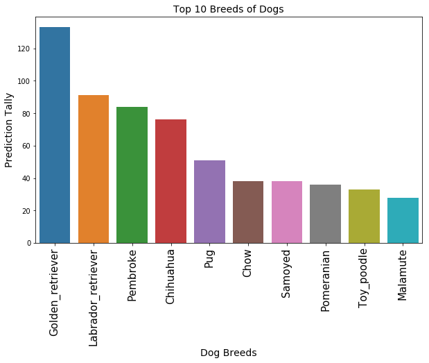

```python
plt.figure(figsize = (10,6))
ax = sns.barplot(x = master_tweet_merge['Prediction1'].value_counts()[0:10].index,
            y =master_tweet_merge['Prediction1'].value_counts()[0:10],
            data = master_tweet_merge);
ax.set_xticklabels(ax.get_xticklabels(),rotation = 90, fontsize = 15);
plt.xlabel("Dog Breeds",fontsize = 14);
plt.ylabel("Prediction Tally",fontsize = 14);
plt.title("Top 10 Breeds of Dogs",fontsize = 14);
```

#### Other metrics to support our top breed - Golden Retriever

```python
# Top Breed (Golden Retriever); Most Prediction tally counts
master_tweet_merge.Prediction1.value_counts().nlargest(1)
```

```
Golden_retriever    133
Name: Prediction1, dtype: int64
```

```python
# Dataframe with some of the top Golden Retriever tweets
df_gold_ret = master_tweet_merge.query('Prediction1 == "Golden_retriever"')
df_gold_ret.head(3)
```

|  | tweet_id | timestamp | text | rating_numerator | rating_denominator | name | dog_stage | favorite_count | lang | retweet_count | jpg_url | Prediction1 | Prediction1_Conf | Prediction1_Dog | Prediction2 | Prediction2_Conf | Prediction2_dog | Prediction3 | Prediction3_Conf | Prediction3_dog |
| --- | --- | --- | --- | --- | --- | --- | --- | --- | --- | --- | --- | --- | --- | --- | --- | --- | --- | --- | --- | --- |
| 11 | 666345417576210432 | 2015-11-16 20:01:42 | Look at this jokester thinking seat belt laws ... | 10.0 | 10 | NaN | NaN | 307 | en | 146 | https://pbs.twimg.com/media/CT9Vn7PWoAA_ZCM.jpg | Golden_retriever | 0.858744 | True | Chesapeake_bay_retriever | 0.054787 | True | Labrador_retriever | 0.014241 | True |
| 37 | 667044094246576128 | 2015-11-18 18:17:59 | 12/10 gimme now https://t.co/QZAnwgnOMB | 12.0 | 10 | NaN | NaN | 198 | en | 54 | https://pbs.twimg.com/media/CUHREBXXAAE6A9b.jpg | Golden_retriever | 0.765266 | True | Labrador_retriever | 0.206694 | True | Seat_belt | 0.010667 | False |
| 45 | 667160273090932737 | 2015-11-19 01:59:39 | This is Bradlay. He is a Ronaldinho Matsuyama ... | 11.0 | 10 | Bradlay | NaN | 268 | en | 66 | https://pbs.twimg.com/media/CUI6uuaW4AAvCIs.jpg | Golden_retriever | 0.471351 | True | Miniature_poodle | 0.091992 | True | Standard_poodle | 0.087385 | True |

### 2 - Insight

##### Dog Names most frequently used - Goes to Charlie

- Based on the master dataset here are the most frequently used dog names.

```python
# Charlie is the Top Dog name
freq_names = master_tweet_merge.name.value_counts().nlargest(10)
freq_names
```

```
Charlie    11
Lucy       10
Oliver     10
Cooper     10
Penny       9
Tucker      9
Sadie       8
Winston     8
Toby        7
Daisy       7
Name: name, dtype: int64
```

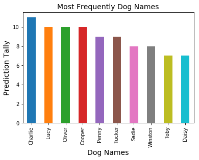

```python
# Top Dog Names
freq_names.plot(kind='bar')
plt.xlabel("Dog Names",fontsize = 14);
plt.ylabel("Prediction Tally",fontsize = 14);
plt.title("Most Frequently Dog Names",fontsize = 14);
```

### 3 - Insight

```python
# Highest rating of numerator for the master tweet dataset
rate = master_tweet_merge['rating_numerator'].value_counts().nlargest(5)
rate
```

```
12.0    433
10.0    395
11.0    376
13.0    249
9.0     136
Name: rating_numerator, dtype: int64
```

### 4 - Insight

##### The Favorite Tweet Dog

- Based on the master dataset the favorite with the most tweet goes to a Lakeland Terrier!

```python
# Top Favorite tweet and the Photo along with it!
# It goes to a dog in the "Puppo" dog stage
top_fav_tweet = master_tweet_merge.sort_values('favorite_count',ascending=False);
top_fav_tweet = top_fav_tweet[['tweet_id','favorite_count','jpg_url','dog_stage','Prediction1']]
top_fav_tweet.head()
```

|  | tweet_id | favorite_count | jpg_url | dog_stage | Prediction1 |
| --- | --- | --- | --- | --- | --- |
| 1571 | 822872901745569793 | 132810 | https://pbs.twimg.com/media/C2tugXLXgAArJO4.jpg | puppo | Lakeland_terrier |
| 1122 | 744234799360020481 | 131075 | https://pbs.twimg.com/ext_tw_video_thumb/74423... | doggo | Labrador_retriever |
| 1816 | 879415818425184262 | 107956 | https://pbs.twimg.com/ext_tw_video_thumb/87941... | NaN | English_springer |
| 1480 | 807106840509214720 | 107015 | https://pbs.twimg.com/ext_tw_video_thumb/80710... | NaN | Chihuahua |
| 1766 | 866450705531457537 | 106827 | https://pbs.twimg.com/media/DAZAUfBXcAAG_Nn.jpg | pupper | French_bulldog |

```python
# Here's the photo for the proof
url = master_tweet_merge.jpg_url[1571]
r = requests.get(url)
Image.open(BytesIO(r.content))
```

[output not shown]